# Lab 4b

Jas Sur

3/1/2022

## Question 1

### a. Set up the data frame, named “chem”, with “Bolt” and “Chemical” factors, “strength” as response.

```r
chemical.data <- rep(c(1,2,3,4), each=5)
bolt.data <- rep(c(1,2,3,4,5), times=4)

strength <- c(73,68,74,71,67,73,67,75,72,70,75,68,78,73,68,73,71,75,75,69)

effect <- data.frame(strength, chemical.data, bolt.data)
effect$chemical <- factor(chemical.data, levels=c(1,2,3,4), labels =c("Chemical1", "Chemical2", "Chemical3", "Chemical4"))
effect$bolt <- factor(bolt.data, levels=c(1,2,3,4,5), labels=c("Bolt1", "Bolt2", "Bolt3", "Bolt4", "Bolt5"))
# effect$chemical<- as.factor(chemical.data)
# effect$bolt<- as.factor(bolt.data)
chemical <-effect$chemical
bolt <- effect$bolt
str(effect)
```

```
## 'data.frame':    20 obs. of  5 variables:
##  $ strength     : num  73 68 74 71 67 73 67 75 72 70 ...
##  $ chemical.data: num  1 1 1 1 1 2 2 2 2 2 ...
##  $ bolt.data    : num  1 2 3 4 5 1 2 3 4 5 ...
##  $ chemical     : Factor w/ 4 levels "Chemical1","Chemical2",..: 1 1 1 1 1 2 2 2 2 2 ...
##  $ bolt         : Factor w/ 5 levels "Bolt1","Bolt2",..: 1 2 3 4 5 1 2 3 4 5 ...
```

```r
head(effect)
```

```
##   strength chemical.data bolt.data  chemical  bolt
## 1       73             1         1 Chemical1 Bolt1
## 2       68             1         2 Chemical1 Bolt2
## 3       74             1         3 Chemical1 Bolt3
## 4       71             1         4 Chemical1 Bolt4
## 5       67             1         5 Chemical1 Bolt5
## 6       73             2         1 Chemical2 Bolt1
```

### b. Any evidence that the Chemical affect Strength ? Note: Chemical is the treatment factor.

```r
tapply(strength, list(chemical, bolt), mean)
```

```
##           Bolt1 Bolt2 Bolt3 Bolt4 Bolt5
## Chemical1    73    68    74    71    67
## Chemical2    73    67    75    72    70
## Chemical3    75    68    78    73    68
## Chemical4    73    71    75    75    69
```

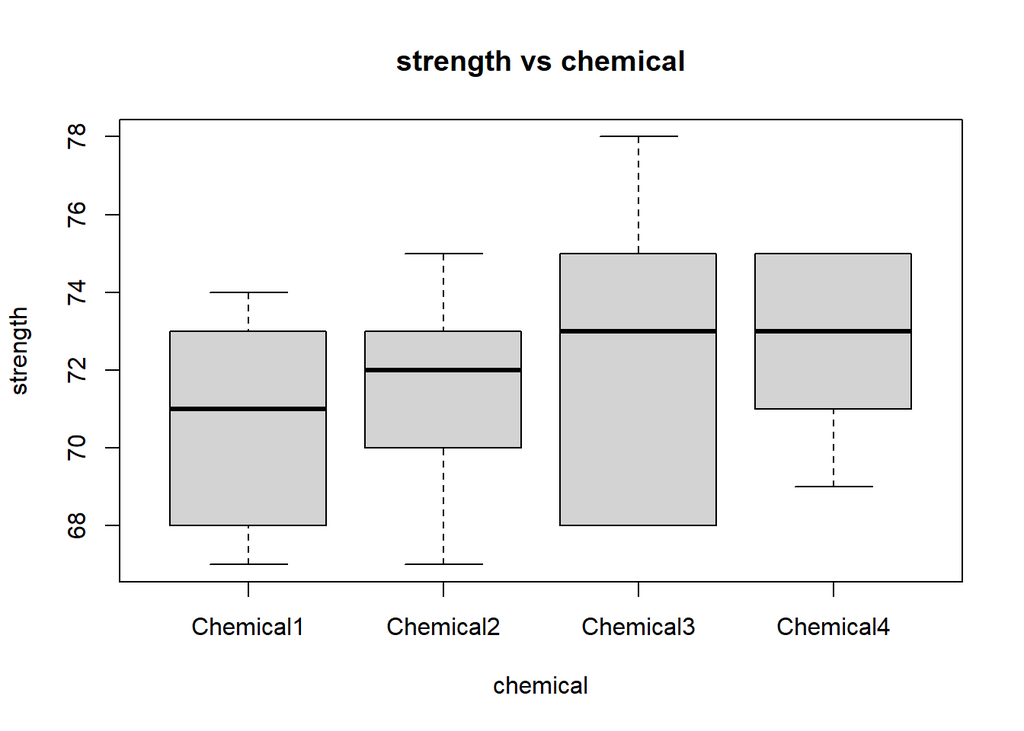

```r
boxplot(strength~chemical, main="strength vs chemical")
```

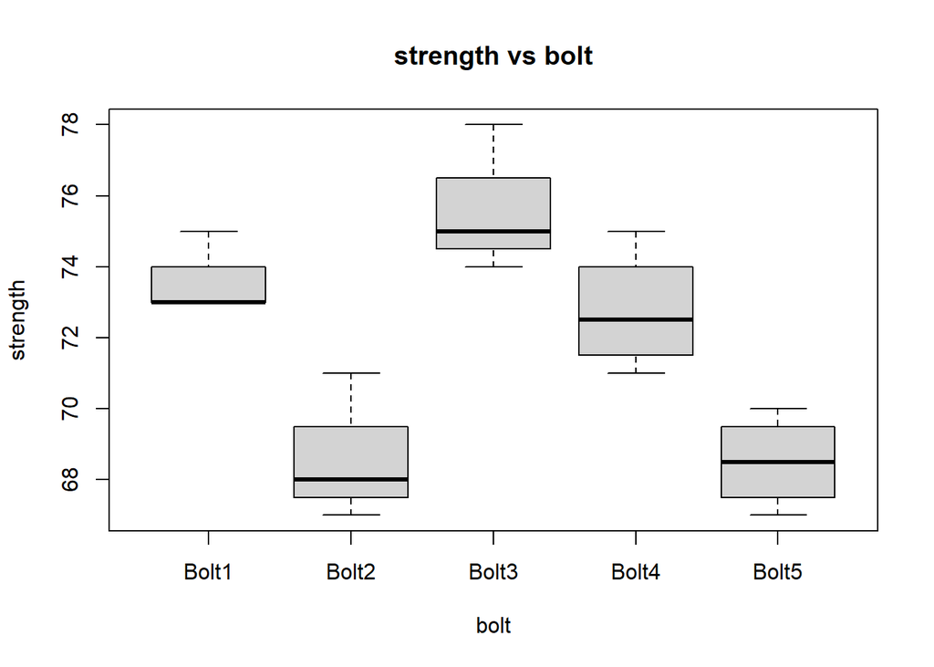

```r
boxplot(strength~bolt, main="strength vs bolt")
```

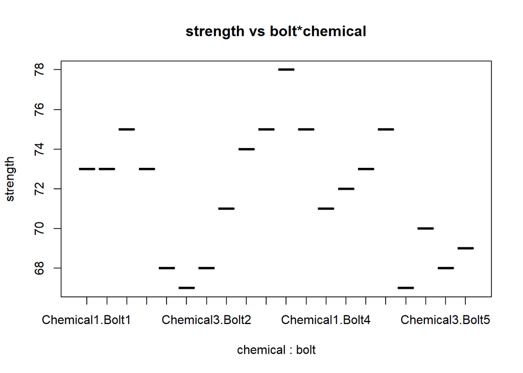

```r
boxplot(strength~chemical*bolt, main="strength vs bolt*chemical")
```

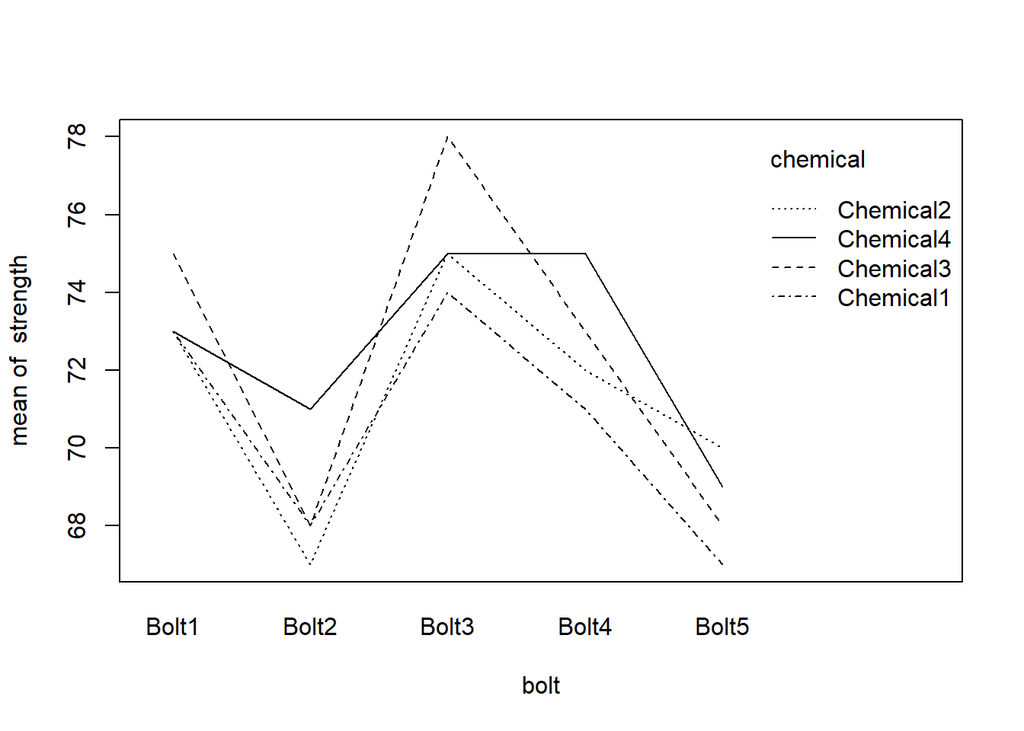

```r
interaction.plot(bolt, chemical, strength)
```

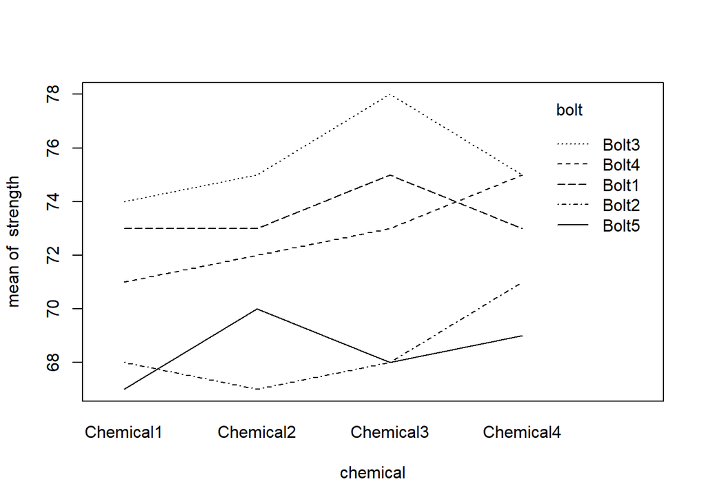

```r
interaction.plot(chemical, bolt, strength)
```

### b.

> Any evidence that the Chemical affect Strength?Note: Chemical is the treatment factor.

```r
effect.interaction.mod <- aov(strength~chemical*bolt, data=effect)
summary.aov(effect.interaction.mod)
```

```
##               Df Sum Sq Mean Sq
## chemical       3  12.95    4.32
## bolt           4 157.00   39.25
## chemical:bolt 12  21.80    1.82
```

Since n=1 (single replicate) ; MSE =SSE/ab(n-1), MSE can’t be calculated! We can assume no significant between chemical and bolt

We need to run Tukey1df to check if the interaction term is significant

```r
library(daewr)
tukey.interaction <- data.frame(strength, chemical, bolt)
Tukey1df(tukey.interaction)
```

```
## Source           df     SS        MS        F     Pr>F
## A                 3   12.95    4.3167
## B                 4   157    39.25
## Error            12   21.8    29.0667
## NonAdditivity     1   0.2081    0.2081    0.11    0.7508
## Residual         11   21.5919    1.9629
```

> NonAdditivity is 0.7508, so interaction term is not significant

```r
effect.mod <- aov(strength~chemical+bolt, data=effect)
summary.aov(effect.mod)
```

```
##             Df Sum Sq Mean Sq F value   Pr(>F)
## chemical     3  12.95    4.32   2.376    0.121
## bolt         4 157.00   39.25  21.606 2.06e-05 ***
## Residuals   12  21.80    1.82
## ---
## Signif. codes:  0 '***' 0.001 '**' 0.01 '*' 0.05 '.' 0.1 ' ' 1
```

> The Chemical has pvalue >0.05, so the null hypothesis that the chemical doesn’t affect strength is accepted and the alternative hypothesis that the chemical affect strength is rejected

#### Is Bolt is an effective blocking factor?

> Since it’s pvalue is significant, the blocking factor could be effective. We need to check if the MSE increases or decreases without blocking factor. If it increases, then we know that Blocking factor is effective.

```r
effect.1.mod <- aov(strength~chemical, data=effect)
summary.aov(effect.1.mod)
```

```
##             Df Sum Sq Mean Sq F value Pr(>F)
## chemical     3  12.95   4.317   0.386  0.764
## Residuals   16 178.80  11.175
```

> MSE increases significantly without bolt, so yes the bolt act as an effective blocking factor

### c. Perform a TukeyHSD to compare the treatment means. Which Chemical is the preferred(bring the highest strength)

```r
tukey <- TukeyHSD(effect.mod)
tukey
```

```
##   Tukey multiple comparisons of means
##     95% family-wise confidence level
##
## Fit: aov(formula = strength ~ chemical + bolt, data = effect)
##
## $chemical
##                     diff        lwr      upr     p adj
## Chemical2-Chemical1  0.8 -1.7308322 3.330832 0.7852734
## Chemical3-Chemical1  1.8 -0.7308322 4.330832 0.2042593
## Chemical4-Chemical1  2.0 -0.5308322 4.530832 0.1417326
## Chemical3-Chemical2  1.0 -1.5308322 3.530832 0.6540138
## Chemical4-Chemical2  1.2 -1.3308322 3.730832 0.5182726
## Chemical4-Chemical3  0.2 -2.3308322 2.730832 0.9952030
##
## $bolt
##              diff        lwr        upr     p adj
## Bolt2-Bolt1 -5.00  -8.037831 -1.9621691 0.0015656
## Bolt3-Bolt1  2.00  -1.037831  5.0378309 0.2814173
## Bolt4-Bolt1 -0.75  -3.787831  2.2878309 0.9295872
## Bolt5-Bolt1 -5.00  -8.037831 -1.9621691 0.0015656
## Bolt3-Bolt2  7.00   3.962169 10.0378309 0.0000717
## Bolt4-Bolt2  4.25   1.212169  7.2878309 0.0056966
## Bolt5-Bolt2  0.00  -3.037831  3.0378309 1.0000000
## Bolt4-Bolt3 -2.75  -5.787831  0.2878309 0.0830636
## Bolt5-Bolt3 -7.00 -10.037831 -3.9621691 0.0000717
## Bolt5-Bolt4 -4.25  -7.287831 -1.2121691 0.0056966
```

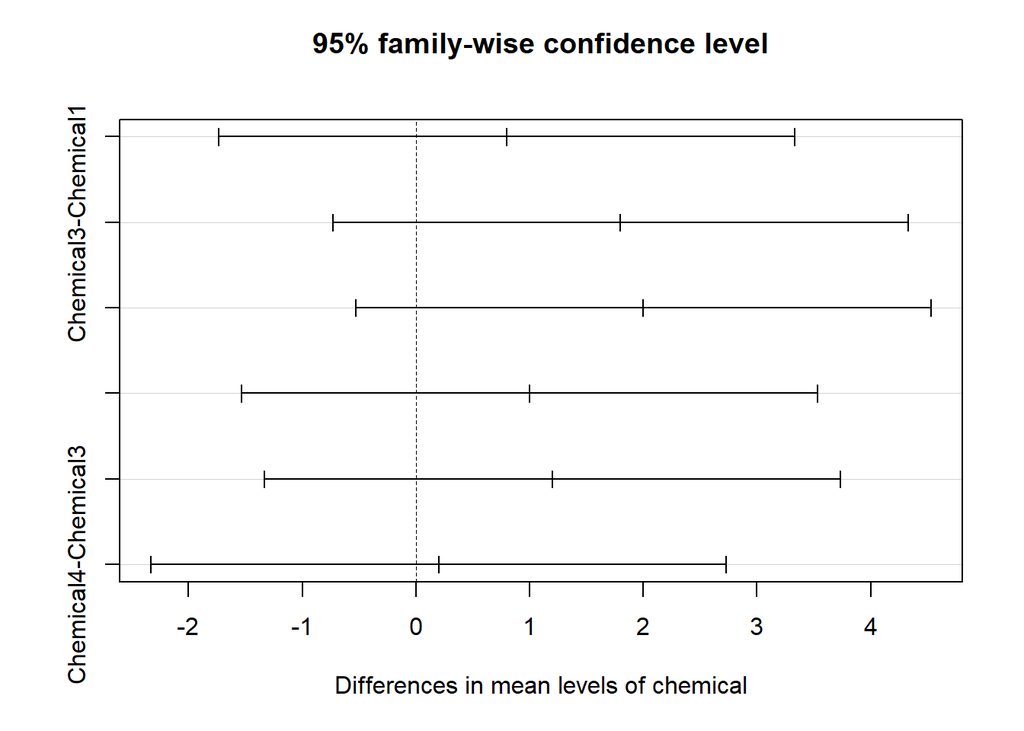

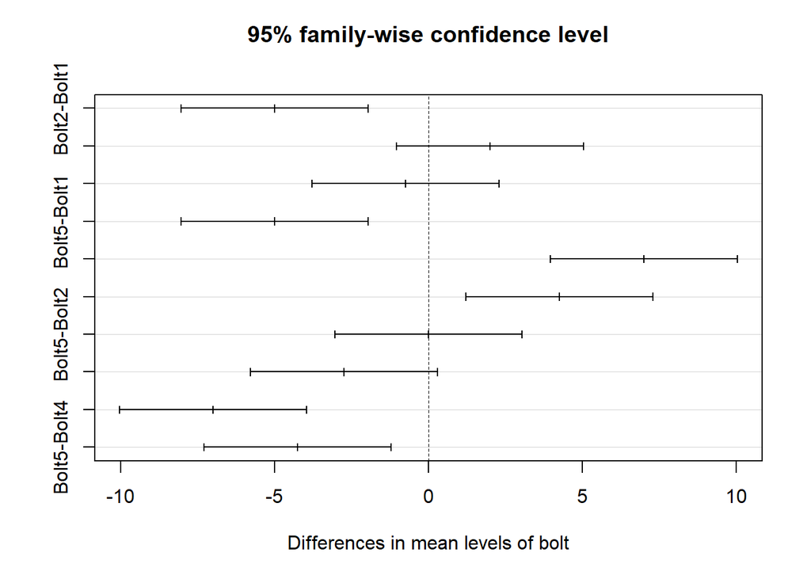

```r
plot(tukey)
```

Chemical difference of mean is not significant, so it’s clear chemical doesn’t affect the strength. Some of the bolt values have pvalue <0.05, so it’s clearly affect the strength.

### d. Check the assumptions of the residuals.

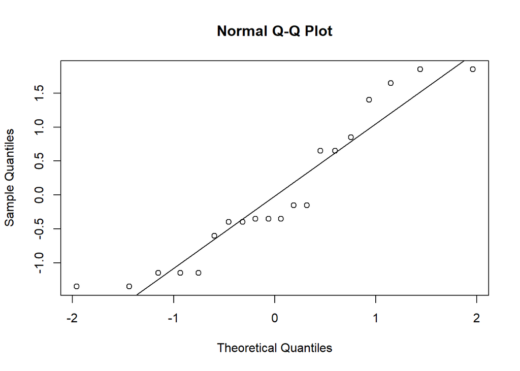

```r
res <- residuals(effect.mod)

qqnorm(res)
qqline(res)
```

```r
shapiro.test(res)
```

```
##
##  Shapiro-Wilk normality test
##
## data:  res
## W = 0.8996, p-value = 0.04054
```

```r
bartlett.test(res~bolt)
```

```
##
##  Bartlett test of homogeneity of variances
##
## data:  res by bolt
## Bartlett's K-squared = 0.65699, df = 4, p-value = 0.9565
```

```r
bartlett.test(res~chemical)
```

```
##
##  Bartlett test of homogeneity of variances
##
## data:  res by chemical
## Bartlett's K-squared = 2.6757, df = 3, p-value = 0.4444
```

The data doesn’t appear to be normal, but it has const variance.

## Question 2

### set up the data frame named eye, subject, distance as factors and time as response

```r
subject.data <-rep(c(1,2,3,4,5), time=4)
distance.data <- rep(c(4,6,8,10), each=5)
time <-c(10,6,6,6,6,7,6,6,1,6,5,3,3,2,5,6,4,4,2,3)
eye <- data.frame(time, subject.data, distance.data)

eye$subject <- factor(subject.data, c(1,2,3,4,5), label=c("Sub1","Sub2", "Sub3","Sub4", "Sub5"))

eye$distance <- factor(distance.data, c(4,6,8,10), label=c("Dist4","Dist6", "Dist8","Dist10"))
head(eye)
```

```
##   time subject.data distance.data subject distance
## 1   10            1             4    Sub1    Dist4
## 2    6            2             4    Sub2    Dist4
## 3    6            3             4    Sub3    Dist4
## 4    6            4             4    Sub4    Dist4
## 5    6            5             4    Sub5    Dist4
## 6    7            1             6    Sub1    Dist6
```

```r
str(eye)
```

```
## 'data.frame':    20 obs. of  5 variables:
##  $ time         : num  10 6 6 6 6 7 6 6 1 6 ...
##  $ subject.data : num  1 2 3 4 5 1 2 3 4 5 ...
##  $ distance.data: num  4 4 4 4 4 6 6 6 6 6 ...
##  $ subject      : Factor w/ 5 levels "Sub1","Sub2",..: 1 2 3 4 5 1 2 3 4 5 ...
##  $ distance     : Factor w/ 4 levels "Dist4","Dist6",..: 1 1 1 1 1 2 2 2 2 2 ...
```

### b. build a regression model named eye.mod. Is “subject” an effecting blocking factor?

```r
attach(eye)
eye.mod <- aov(time~subject*distance, data=effect)
summary.aov(eye.mod)
```

```
##                  Df Sum Sq Mean Sq
## subject           4  36.30   9.075
## distance          3  32.95  10.983
## subject:distance 12  15.30   1.275
```

Since n=1, so there are no pvalues. We need to check it using Tukeys1df

```r
library(daewr)
tukey.interaction <- data.frame(time, subject, distance)
Tukey1df(tukey.interaction)
```

```
## Source           df     SS        MS        F     Pr>F
## A                 4   36.3    9.075
## B                 3   32.95    10.9833
## Error            12   15.3    11.475
## NonAdditivity     1   0.2749    0.2749    0.2    0.6624
## Residual         11   15.0251    1.3659
```

NonAdditivity is 0.6624, so interaction is not significant.

```r
attach(eye)
eye.mod <- aov(time~subject+distance, data=effect)
summary.aov(eye.mod)
```

```
##             Df Sum Sq Mean Sq F value  Pr(>F)
## subject      4  36.30   9.075   7.118 0.00355 **
## distance     3  32.95  10.983   8.614 0.00254 **
## Residuals   12  15.30   1.275
## ---
## Signif. codes:  0 '***' 0.001 '**' 0.01 '*' 0.05 '.' 0.1 ' ' 1
```

It’s evident that both subject and distance are both significant.

```r
attach(eye)
eye.distance.mod <- aov(time~distance, data=effect)
summary.aov(eye.distance.mod)
```

```
##             Df Sum Sq Mean Sq F value Pr(>F)
## distance     3  32.95  10.983   3.406 0.0434 *
## Residuals   16  51.60   3.225
## ---
## Signif. codes:  0 '***' 0.001 '**' 0.01 '*' 0.05 '.' 0.1 ' ' 1
```

Blocking factor decreases the MSE value, so it is effective

```r
tukey.distance <- TukeyHSD(eye.distance.mod)
tukey.distance
```

```
##   Tukey multiple comparisons of means
##     95% family-wise confidence level
##
## Fit: aov(formula = time ~ distance, data = effect)
##
## $distance
##              diff       lwr        upr     p adj
## Dist6-Dist4  -1.6 -4.849494 1.64949387 0.5121274
## Dist8-Dist4  -3.2 -6.449494 0.04949387 0.0543435
## Dist10-Dist4 -3.0 -6.249494 0.24949387 0.0756883
## Dist8-Dist6  -1.6 -4.849494 1.64949387 0.5121274
## Dist10-Dist6 -1.4 -4.649494 1.84949387 0.6161363
## Dist10-Dist8  0.2 -3.049494 3.44949387 0.9979766
```

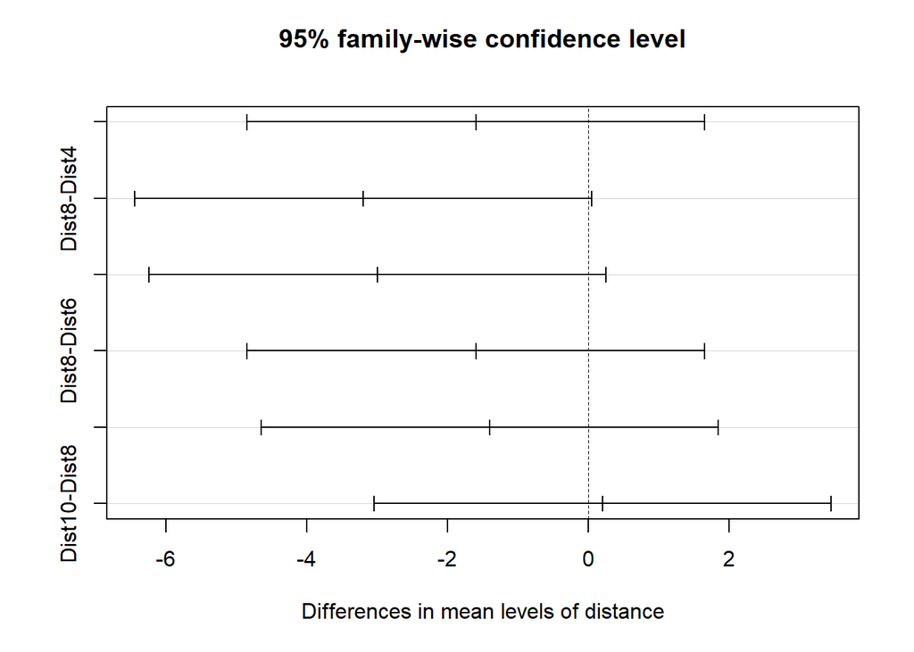

```r
plot(tukey.distance)
```

```r
MSE <-1.275
trt.means <-tapply(time, list(subject, distance), mean)
power.anova.test(groups=5, n=2, between.var = var(trt.means), within.var = MSE,
                 sig.level = 0.05)
```

```
##
##      Balanced one-way analysis of variance power calculation
##
##          groups = 5
##               n = 2
##     between.var = 3.20, 1.80, 1.40, 2.20, 1.80, 5.70, 2.35, 2.80, 1.40, 2.35, 1.80, 1.15, 2.20, 2.80, 1.15, 2.20
##      within.var = 1.275
##       sig.level = 0.05
##           power = 0.6209504, 0.3863123, 0.3087149, 0.4602038, 0.3863123, 0.8639282, 0.4866474, 0.5611778, 0.3087149, 0.4866474, 0.3863123, 0.2592861, 0.4602038, 0.5611778, 0.2592861, 0.4602038
##
## NOTE: n is number in each group
```

```r
detach()
```

## Question 3

### a. Setup a dataframe manually to use the Latin square design

```r
operator <- factor(rep(c(1,2,3,4), time=4), level=c(1,2,3,4),
                   label=c("Op1", "Op2", "Op3", "Op4"))
order <- factor(rep(c(1,2,3,4), each=4), level=c(1,2,3,4),
                label=c("Order1","Order2","Order3","Order4" ))
r1 <- c('C','D','A','B')
r2 <- c('B','C','D','A')
r3 <- c('A','B','C','D')
r4 <- c('D','A','B','C')
treat <- c(r1,r2,r3,r4)
time <- c(10,14,7,8,7,18,11,8,5,10,11,9,10,10,12,14)

experiment <-data.frame(operator, order, treat, time)
str(experiment)
```

```
## 'data.frame':    16 obs. of  4 variables:
##  $ operator: Factor w/ 4 levels "Op1","Op2","Op3",..: 1 2 3 4 1 2 3 4 1 2 ...
##  $ order   : Factor w/ 4 levels "Order1","Order2",..: 1 1 1 1 2 2 2 2 3 3 ...
##  $ treat   : chr  "C" "D" "A" "B" ...
##  $ time    : num  10 14 7 8 7 18 11 8 5 10 ...
```

```r
head(experiment)
```

```
##   operator  order treat time
## 1      Op1 Order1     C   10
## 2      Op2 Order1     D   14
## 3      Op3 Order1     A    7
## 4      Op4 Order1     B    8
## 5      Op1 Order2     B    7
## 6      Op2 Order2     C   18
```

```r
attach(experiment)
```

### b. Build a regression model, using aov(). Do the treatment affect the assembly time?

```r
time.aov <- aov(time~treat+order+operator)
summary(time.aov)
```

```
##             Df Sum Sq Mean Sq F value  Pr(>F)
## treat        3   72.5  24.167  13.810 0.00421 **
## order        3   18.5   6.167   3.524 0.08852 .
## operator     3   51.5  17.167   9.810 0.00993 **
## Residuals    6   10.5   1.750
## ---
## Signif. codes:  0 '***' 0.001 '**' 0.01 '*' 0.05 '.' 0.1 ' ' 1
```

The pvalue for treatment is significant, so it does affect the assmebly time.

### c. Find the lowest assembly time.

```r
tukey <- TukeyHSD(time.aov)
tukey
```

```
##   Tukey multiple comparisons of means
##     95% family-wise confidence level
##
## Fit: aov(formula = time ~ treat + order + operator)
##
## $treat
##      diff        lwr       upr     p adj
## B-A  1.75 -1.4881345 4.9881345 0.3304308
## C-A  5.75  2.5118655 8.9881345 0.0034505
## D-A  3.50  0.2618655 6.7381345 0.0363534
## C-B  4.00  0.7618655 7.2381345 0.0202927
## D-B  1.75 -1.4881345 4.9881345 0.3304308
## D-C -2.25 -5.4881345 0.9881345 0.1761447
##
## $order
##                diff        lwr       upr     p adj
## Order2-Order1  1.25 -1.9881345 4.4881345 0.5756823
## Order3-Order1 -1.00 -4.2381345 2.2381345 0.7191024
## Order4-Order1  1.75 -1.4881345 4.9881345 0.3304308
## Order3-Order2 -2.25 -5.4881345 0.9881345 0.1761447
## Order4-Order2  0.50 -2.7381345 3.7381345 0.9474067
## Order4-Order3  2.75 -0.4881345 5.9881345 0.0924529
##
## $operator
##          diff        lwr         upr     p adj
## Op2-Op1  5.00  1.7618655  8.23813449 0.0070204
## Op3-Op1  2.25 -0.9881345  5.48813449 0.1761447
## Op4-Op1  1.75 -1.4881345  4.98813449 0.3304308
## Op3-Op2 -2.75 -5.9881345  0.48813449 0.0924529
## Op4-Op2 -3.25 -6.4881345 -0.01186551 0.0492740
## Op4-Op3 -0.50 -3.7381345  2.73813449 0.9474067
```

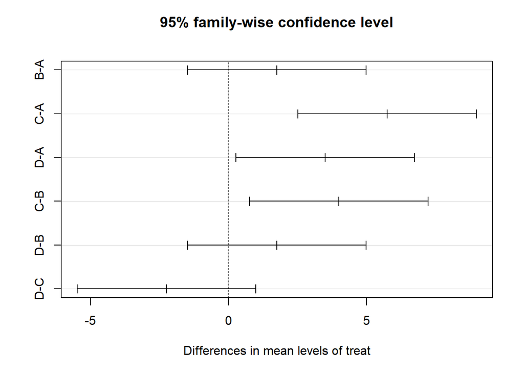

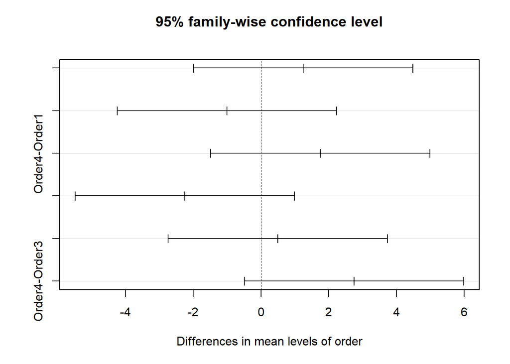

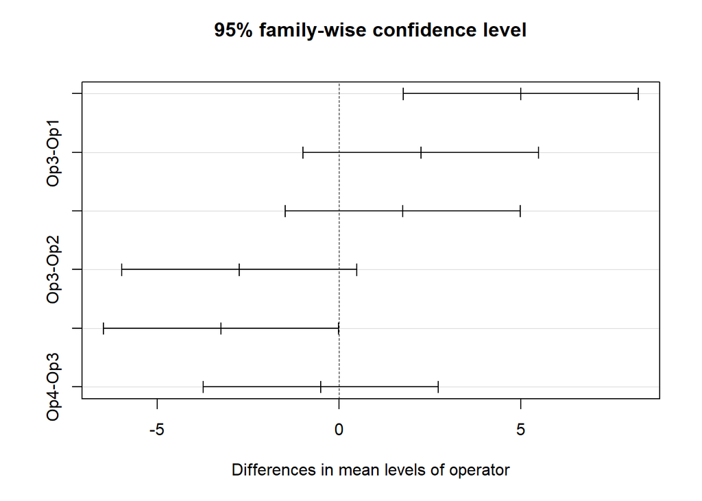

```r
plot(tukey)
```

```r
detach()
```

A has smallest assembly time